# EDA

# EDA for Household Energy Insecurity

First, I calculated the average and range of both EI and PO proportions across all 50 states plus the District of Columbia. The average level of energy insecurity (EI) is about 0.256, with values ranging from 0.15–0.4. For power outage proportion (PO), the average is roughly 0.182, and the range spans from 0.04–0.6.

The distribution plots are shown below.

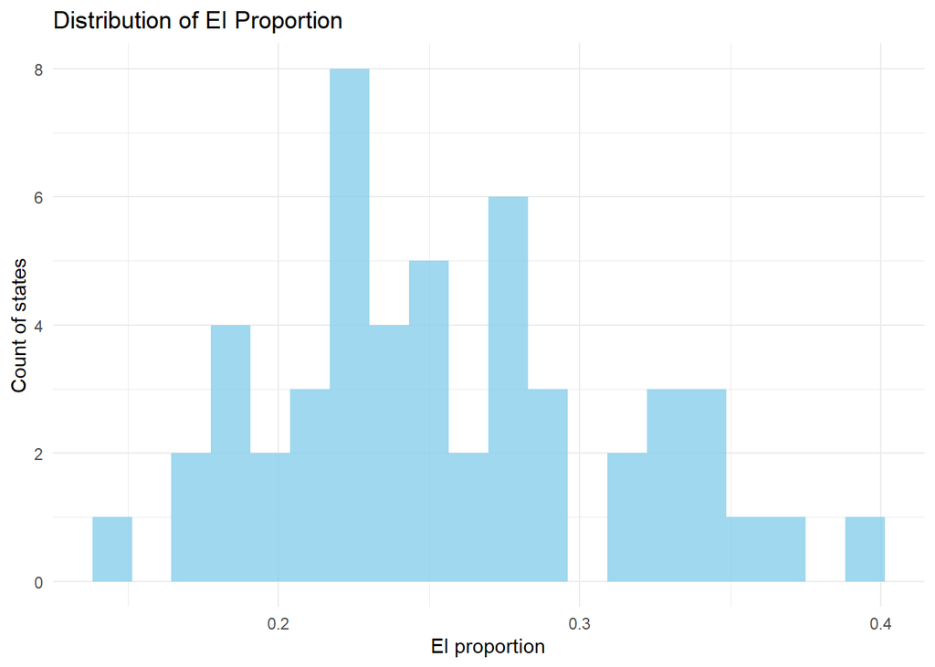

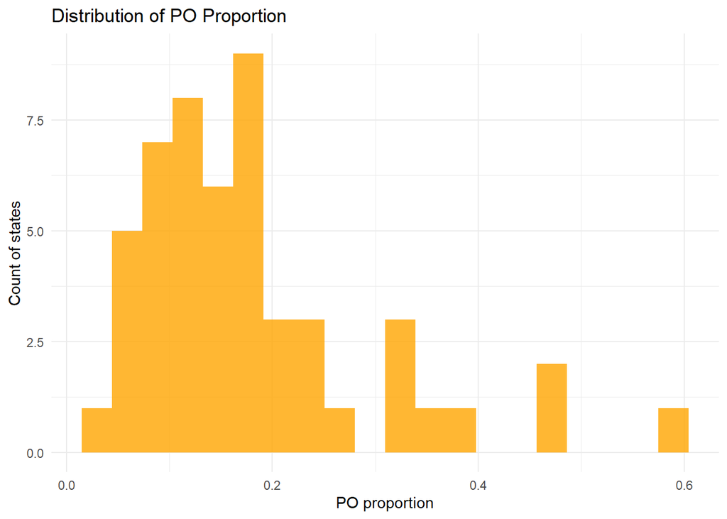

To examine whether the two variables are related, I also put them together. The plot for both is below.

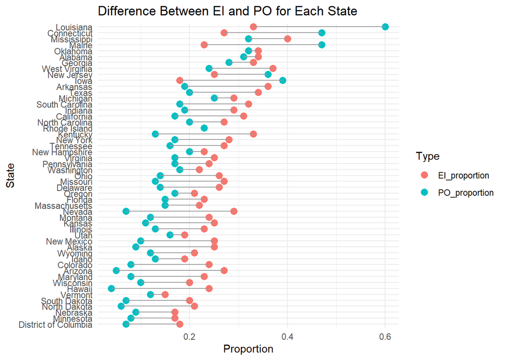

I have also computed the ranks of EI and PO for each state, the results are shown in the table below.

Ranks of EI and PO by State

| state | EI_rank | PO_rank |
| --- | --- | --- |
| Mississippi | 1 | 5 |
| West Virginia | 2 | 9 |
| Arkansas | 3 | 12 |
| Alabama | 4 | 6 |
| Oklahoma | 4 | 5 |
| Texas | 4 | 11 |
| Georgia | 5 | 7 |
| Kentucky | 5 | 18 |
| Louisiana | 5 | 1 |
| South Carolina | 6 | 13 |
| California | 7 | 14 |
| Indiana | 8 | 12 |
| Michigan | 8 | 8 |
| Nevada | 8 | 24 |
| New York | 9 | 14 |
| Arizona | 10 | 26 |
| Connecticut | 10 | 2 |
| Missouri | 10 | 18 |
| North Carolina | 10 | 11 |
| Tennessee | 10 | 15 |
| Delaware | 11 | 17 |
| Ohio | 11 | 17 |
| Alaska | 12 | 22 |
| Kansas | 12 | 20 |
| New Jersey | 12 | 4 |
| New Mexico | 12 | 21 |
| Virginia | 12 | 14 |
| Colorado | 13 | 23 |
| Hawaii | 13 | 27 |
| Montana | 13 | 19 |
| Pennsylvania | 13 | 14 |
| Florida | 14 | 16 |
| Illinois | 14 | 18 |
| Maine | 14 | 2 |
| Maryland | 14 | 23 |
| New Hampshire | 14 | 11 |
| Rhode Island | 14 | 10 |
| Massachusetts | 15 | 16 |
| Washington | 15 | 13 |
| North Dakota | 16 | 25 |
| Oregon | 16 | 14 |
| Wyoming | 16 | 19 |
| South Dakota | 17 | 24 |
| Wisconsin | 17 | 21 |
| Idaho | 18 | 18 |
| Utah | 18 | 15 |
| District of Columbia | 19 | 24 |
| Iowa | 19 | 3 |
| Minnesota | 20 | 23 |
| Nebraska | 20 | 22 |
| Vermont | 21 | 19 |

I expected those with high PO rank will also have high EI rank, but the results above don’t really show a clear pattern. So, I run a simple linear regression.

```
##
## Call:
## lm(formula = EI_proportion ~ PO_proportion, data = RECS_EI)
##
## Residuals:
##       Min        1Q    Median        3Q       Max
## -0.115524 -0.035730 -0.004147  0.028972  0.117642
##
## Coefficients:
##               Estimate Std. Error t value Pr(>|t|)
## (Intercept)    0.22217    0.01386  16.032  < 2e-16 ***
## PO_proportion  0.18807    0.06424   2.928  0.00517 **
## ---
## Signif. codes:  0 '***' 0.001 '**' 0.01 '*' 0.05 '.' 0.1 ' ' 1
##
## Residual standard error: 0.05288 on 49 degrees of freedom
## Multiple R-squared:  0.1489, Adjusted R-squared:  0.1315
## F-statistic: 8.571 on 1 and 49 DF,  p-value: 0.005167
```

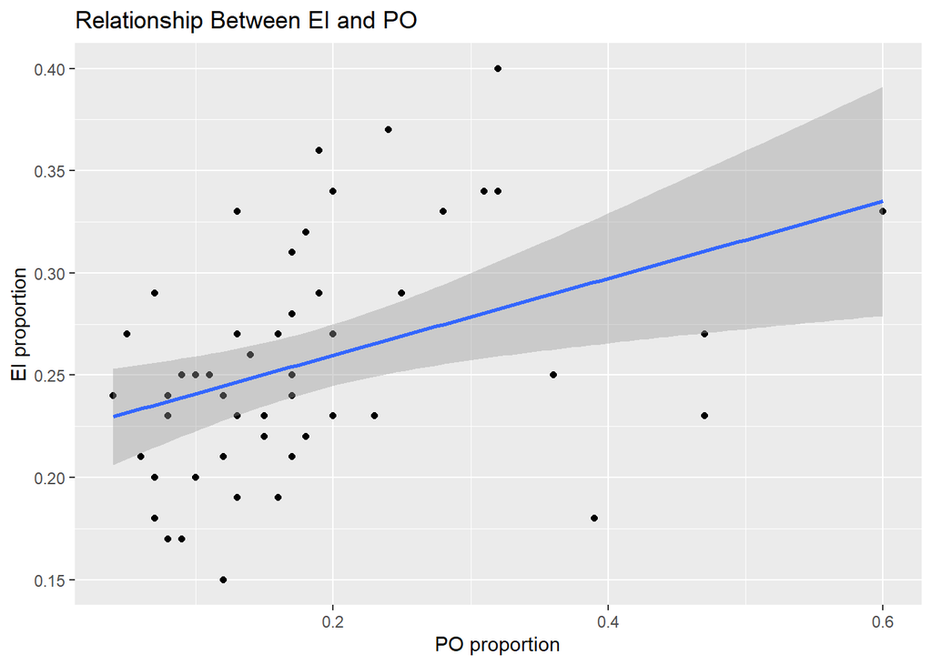

The results indicate a statistically significant but weak positive association: the slope is positive, meaning states with higher outage proportions tend to have slightly higher levels of energy insecurity, but the effect size is small. The model’s R² is only about 0.149, showing that PO explains a relatively small share of the variation in EI across states.

Overall, this analysis suggests that while PO and EI are positively related, outages are unlikely to be the primary driver of state-level energy insecurity. Other structural and socioeconomic factors—such as income, housing conditions, or energy costs—likely play a much larger role in shaping EI outcomes.

# EDA for Census

Our research focuses on mental health, so I first examined the distributions of poor mental health and depression prevalence across census tracts. Both distributions are slightly skewed to the right and unimodal. The average prevalence of poor mental health is 15.17, ranging from 6.1–33%. Depression shows a similar pattern, with an average prevalence of 20.545 and a range of 8.5–36.8%.

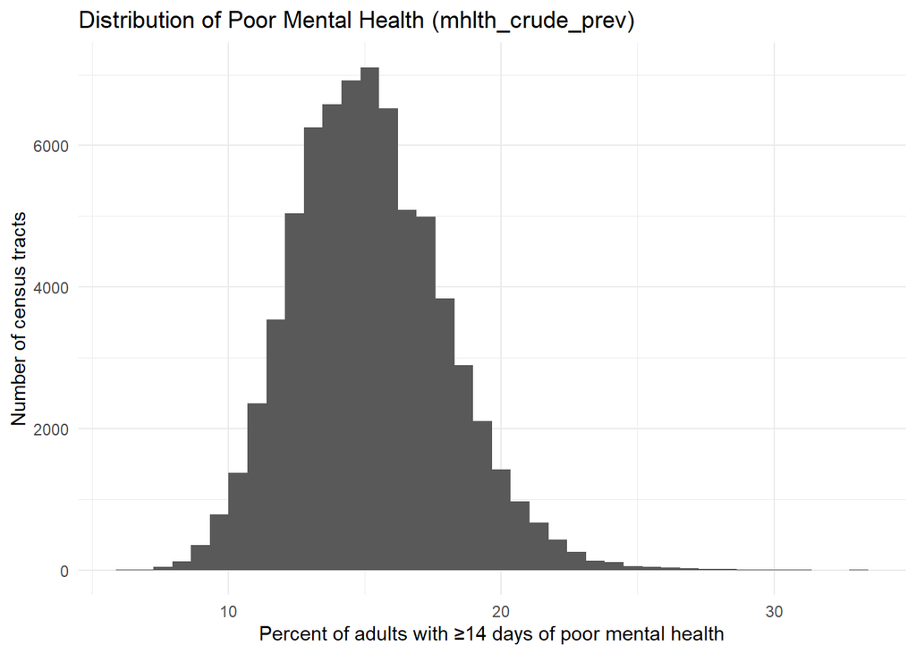

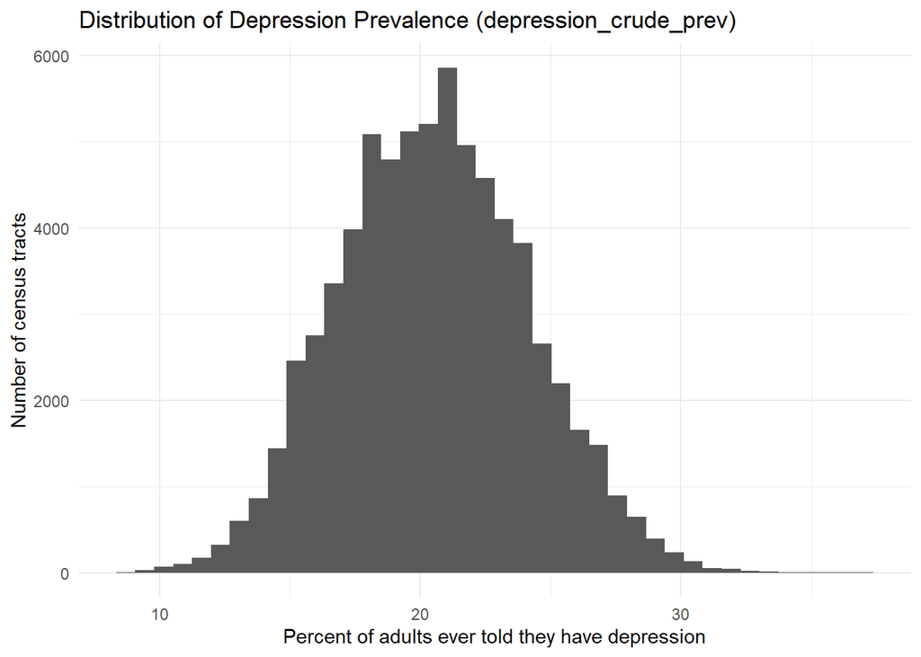

Next, I aggregated the census-tract data to the state level by averaging mental health measures across counties.

State-Level Averages and Rankings for Mental Health Outcomes

| state_desc | mean_mhlth | mean_depression | mhlth_rank | depression_rank |
| --- | --- | --- | --- | --- |
| West Virginia | 18.576 | 27.962 | 1 | 1 |
| Kentucky | 18.496 | 25.883 | 2 | 2 |
| Louisiana | 18.009 | 24.939 | 3 | 6 |
| Tennessee | 17.160 | 25.815 | 4 | 3 |
| Oklahoma | 17.142 | 24.437 | 5 | 8 |
| Ohio | 16.963 | 23.841 | 6 | 11 |
| Alabama | 16.835 | 25.045 | 7 | 5 |
| Arkansas | 16.834 | 24.413 | 8 | 9 |
| Michigan | 16.810 | 20.984 | 9 | 25 |
| Nevada | 16.737 | 19.651 | 10 | 34 |
| Indiana | 16.255 | 23.335 | 11 | 14 |
| Georgia | 16.175 | 19.749 | 12 | 32 |
| Missouri | 16.088 | 23.551 | 13 | 12 |
| Texas | 15.772 | 21.325 | 14 | 24 |
| Pennsylvania | 15.632 | 21.767 | 15 | 22 |
| Utah | 15.563 | 24.607 | 16 | 7 |
| South Carolina | 15.469 | 22.231 | 17 | 20 |
| District of Columbia | 15.437 | 20.138 | 18 | 26 |
| Mississippi | 15.384 | 21.379 | 19 | 23 |
| Arizona | 15.258 | 20.002 | 20 | 27 |
| Florida | 15.200 | 18.247 | 21 | 40 |
| Oregon | 15.162 | 22.823 | 22 | 17 |
| Washington | 14.971 | 25.681 | 23 | 4 |
| California | 14.821 | 17.002 | 24 | 47 |
| New Mexico | 14.639 | 19.653 | 25 | 33 |
| New Hampshire | 14.636 | 22.253 | 26 | 19 |
| Rhode Island | 14.540 | 22.933 | 27 | 16 |
| North Carolina | 14.518 | 22.204 | 28 | 21 |
| Vermont | 14.443 | 24.283 | 29 | 10 |
| Kansas | 14.248 | 19.389 | 30 | 35 |
| New York | 14.206 | 18.412 | 31 | 39 |
| Massachusetts | 14.115 | 19.290 | 32 | 37 |
| Connecticut | 14.054 | 19.937 | 33 | 29 |
| Colorado | 14.030 | 19.903 | 34 | 31 |
| Maine | 14.025 | 23.398 | 35 | 13 |
| Idaho | 13.937 | 19.936 | 36 | 30 |
| Maryland | 13.920 | 17.754 | 37 | 44 |
| Wisconsin | 13.775 | 19.977 | 38 | 28 |
| Delaware | 13.748 | 17.729 | 39 | 45 |
| Virginia | 13.702 | 19.364 | 40 | 36 |
| Iowa | 13.684 | 17.918 | 41 | 42 |
| Montana | 13.564 | 23.081 | 42 | 15 |
| Minnesota | 13.504 | 22.279 | 43 | 18 |
| Wyoming | 13.312 | 18.116 | 44 | 41 |
| Alaska | 13.142 | 17.716 | 45 | 46 |
| Illinois | 12.721 | 16.107 | 46 | 48 |
| North Dakota | 12.505 | 18.870 | 47 | 38 |
| Nebraska | 12.322 | 17.812 | 48 | 43 |
| Hawaii | 11.968 | 14.347 | 49 | 50 |
| South Dakota | 11.255 | 16.099 | 50 | 49 |

The census dataset includes 50 states, resulting in 50 unique ranks for poor mental health and 50 unique ranks for depression.

I did not examine the relationship between depression and poor mental health, because their association is already well established and clearly reflected in the data. Instead, I am more interested in how mental health outcomes relate to energy insecurity.

# EDA for Census and Household Energy Insecurity

I first compared the state-level ranks, and the results are shown in the table below.

State-Level Ranks of EI, PO, Poor Mental Health, and Depression

| state | EI_rank | PO_rank | mhlth_rank | depression_rank |
| --- | --- | --- | --- | --- |
| Mississippi | 1 | 5 | 19 | 23 |
| West Virginia | 2 | 9 | 1 | 1 |
| Arkansas | 3 | 12 | 8 | 9 |
| Alabama | 4 | 6 | 7 | 5 |
| Oklahoma | 4 | 5 | 5 | 8 |
| Texas | 4 | 11 | 14 | 24 |
| Georgia | 5 | 7 | 12 | 32 |
| Kentucky | 5 | 18 | 2 | 2 |
| Louisiana | 5 | 1 | 3 | 6 |
| South Carolina | 6 | 13 | 17 | 20 |
| California | 7 | 14 | 24 | 47 |
| Indiana | 8 | 12 | 11 | 14 |
| Michigan | 8 | 8 | 9 | 25 |
| Nevada | 8 | 24 | 10 | 34 |
| New York | 9 | 14 | 31 | 39 |
| Arizona | 10 | 26 | 20 | 27 |
| Connecticut | 10 | 2 | 33 | 29 |
| Missouri | 10 | 18 | 13 | 12 |
| North Carolina | 10 | 11 | 28 | 21 |
| Tennessee | 10 | 15 | 4 | 3 |
| Delaware | 11 | 17 | 39 | 45 |
| Ohio | 11 | 17 | 6 | 11 |
| Alaska | 12 | 22 | 45 | 46 |
| Kansas | 12 | 20 | 30 | 35 |
| New Jersey | 12 | 4 | NA | NA |
| New Mexico | 12 | 21 | 25 | 33 |
| Virginia | 12 | 14 | 40 | 36 |
| Colorado | 13 | 23 | 34 | 31 |
| Hawaii | 13 | 27 | 49 | 50 |
| Montana | 13 | 19 | 42 | 15 |
| Pennsylvania | 13 | 14 | 15 | 22 |
| Florida | 14 | 16 | 21 | 40 |
| Illinois | 14 | 18 | 46 | 48 |
| Maine | 14 | 2 | 35 | 13 |
| Maryland | 14 | 23 | 37 | 44 |
| New Hampshire | 14 | 11 | 26 | 19 |
| Rhode Island | 14 | 10 | 27 | 16 |
| Massachusetts | 15 | 16 | 32 | 37 |
| Washington | 15 | 13 | 23 | 4 |
| North Dakota | 16 | 25 | 47 | 38 |
| Oregon | 16 | 14 | 22 | 17 |
| Wyoming | 16 | 19 | 44 | 41 |
| South Dakota | 17 | 24 | 50 | 49 |
| Wisconsin | 17 | 21 | 38 | 28 |
| Idaho | 18 | 18 | 36 | 30 |
| Utah | 18 | 15 | 16 | 7 |
| District of Columbia | 19 | 24 | 18 | 26 |
| Iowa | 19 | 3 | 41 | 42 |
| Minnesota | 20 | 23 | 43 | 18 |
| Nebraska | 20 | 22 | 48 | 43 |
| Vermont | 21 | 19 | 29 | 10 |

New Jersey is not included in the census data, likely due to small sample size or CDC’s small-area suppression rules. As a result, we can only see its energy insecurity data in the table, but not its mental health estimates.

Since the table alone is not easy to interpret visually, I created an additional scatterplot using the poor mental health rank and EI rank for each state. (New Jersey does not appear in the plot because its mental health data is missing.)

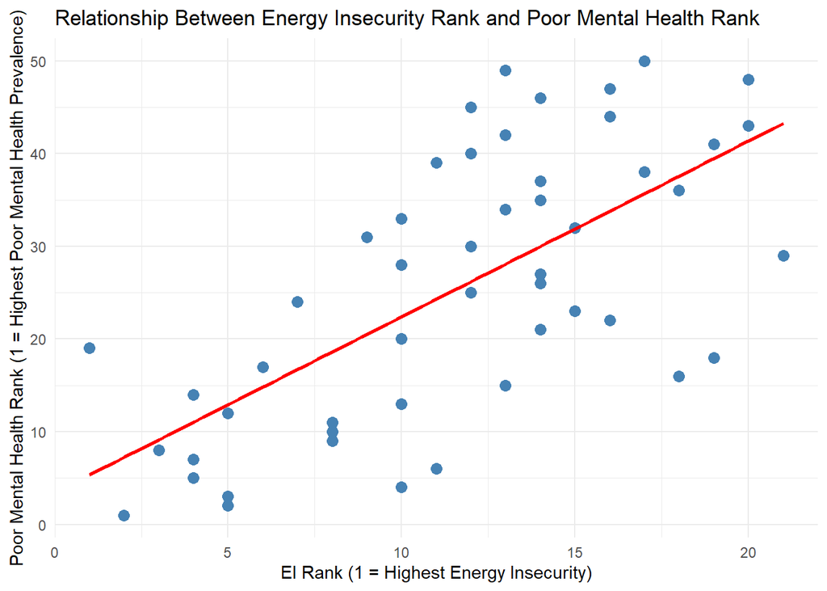

The relationship between EI rank and poor mental health rank has some degree of association in the scatterplot. States with higher energy insecurity tend to also have worse mental health outcomes.

To examine this relationship further, I conducted a simple linear regression using the proportions of energy insecurity and poor mental health, instead of their ranks.

```
##
## Call:
## lm(formula = mean_mhlth ~ EI_proportion, data = ei_mh_prop_clean)
##
## Residuals:
##      Min       1Q   Median       3Q      Max
## -2.62099 -0.88085 -0.04676  0.89633  2.19290
##
## Coefficients:
##               Estimate Std. Error t value Pr(>|t|)
## (Intercept)    10.0167     0.8161  12.274  < 2e-16 ***
## EI_proportion  19.0512     3.1055   6.135 1.56e-07 ***
## ---
## Signif. codes:  0 '***' 0.001 '**' 0.01 '*' 0.05 '.' 0.1 ' ' 1
##
## Residual standard error: 1.246 on 48 degrees of freedom
## Multiple R-squared:  0.4395, Adjusted R-squared:  0.4278
## F-statistic: 37.63 on 1 and 48 DF,  p-value: 1.561e-07
```

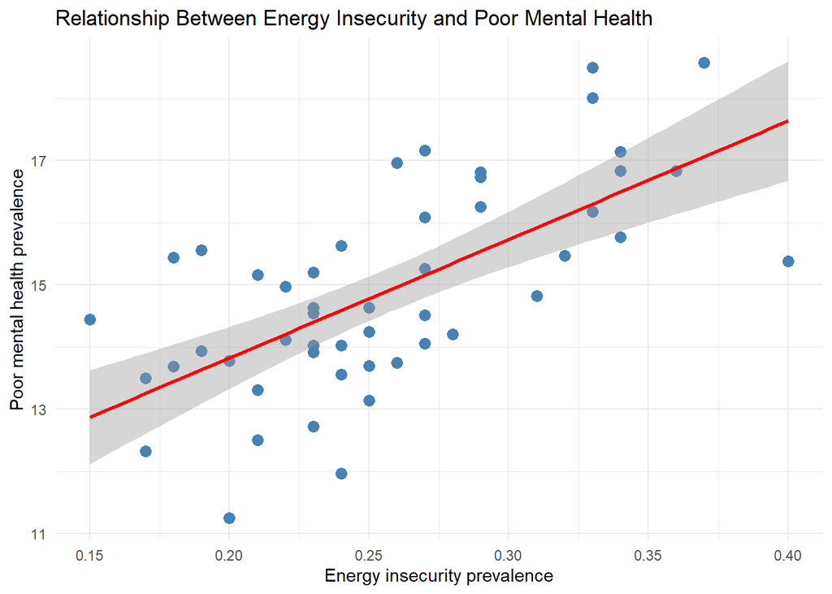

This simple regression supports a moderate positive association, which provides evidence supporting our initial expectation: states with higher energy insecurity tend to report higher levels of poor mental health, and the relationship is both statistically significant and practically meaningful. The model explains about 44% of the variation in poor mental health across states, suggesting that energy insecurity is a meaningful but not exclusive predictor.

# EDA for other health related variables

Given the clear association observed between energy insecurity and poor mental health, it is reasonable to ask whether similar patterns exist for other health-related measures. To explore this possibility, I also conducted a brief examination of additional health indicators available in the PLACES dataset, including mhlth_crude_prev, depression_crude_prev, access2_crude_prev, csmoking_crude_prev, binge_crude_prev, sleep_crude_prev, lpa_crude_prev, ghlth_crude_prev, diabetes_crude_prev, and bphigh_crude_prev.

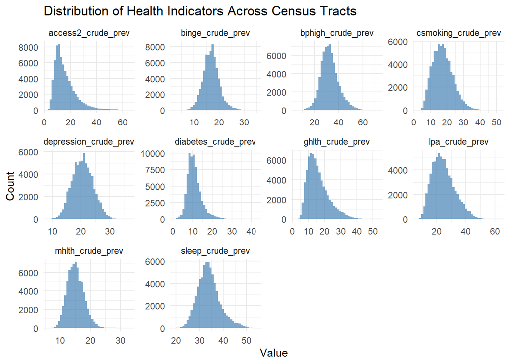

Most of these variables show right-skewed distributions, indicating that while many communities have moderate health burden, some experience disproportionately higher risks.

Next, I examined whether these health indicators also vary systematically with levels of energy insecurity. To do this efficiently, I categorized states into three groups based on tertiles of their energy insecurity prevalence, ranging from low to high EI. I then combined these groups with the state-level averages of each health indicator to compare how health burdens differ across EI levels.

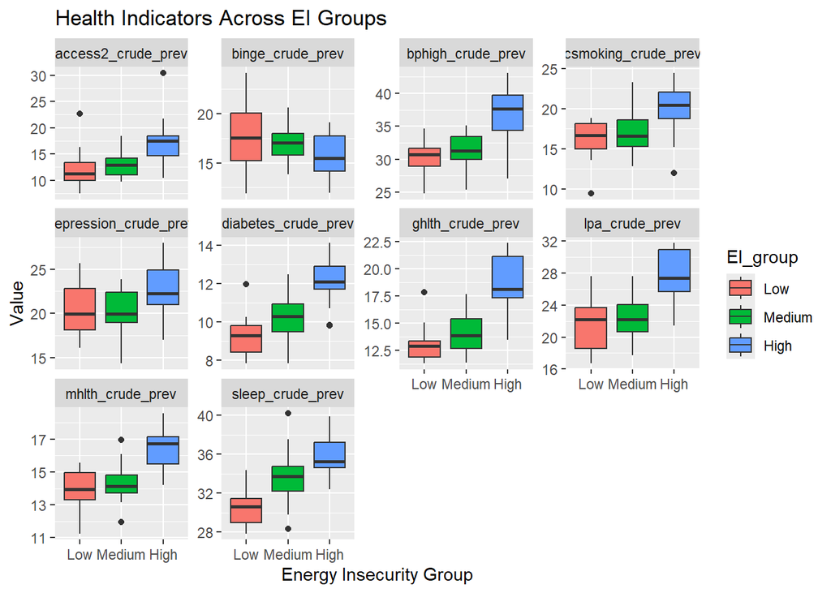

From these plots, we see that states in the high EI group consistently exhibit worse health outcomes across nearly all indicators. This pattern suggests that many of these health-related variables may share a similar relationship with energy insecurity as mental health does, and although they were not part of our initial focus, they also warrant further exploration.